# Day 1: Introduction and Motivation

Aaron R. Williams

```r
library(tidyverse)
```

## Better Data Visualizations

My coworker [Jon Schwabish](https://policyviz.com/) wrote a book called [Better Data Visualizations](https://policyviz.com/pv_books/better-data-visualizations-a-guide-for-scholars-researchers-and-wonks/). Chapter two includes five guidelines for better data visualizations. We will work through the five guidelines with examples in `library(ggplot2)`. Jon has taught me a ton about data viz and [I taught Jon how to use R](https://urban-institute.medium.com/learning-r-a-conversation-982130d75104).

## Guideline 1: Show the Data

> “Your reader can only grasp your point, argument, or story if they see the data.”

Schwabish focuses on communications, but this rule holds true for analysis too. Let’s consider the classic example of [Anscombe’s quartet](https://en.wikipedia.org/wiki/Anscombe%27s_quartet).

### Exercise 1

Step 1: Copy-and-paste the following code to get the Anscombe’s quartet data:

```r
tidy_anscombe <-
  anscombe %>%
  # make the wide data too long
  pivot_longer(everything(), names_to = "names", values_to = "value") %>%
  # split the axis and quartet id
  mutate(
    coord = str_sub(names, start = 1, end = 1),
    quartet = str_sub(names, start = 2, end = 2)
  ) %>%
  group_by(quartet, coord) %>%
  mutate(id = row_number()) %>%
  # make the data tidy
  pivot_wider(id_cols = c(id, quartet), names_from = coord, values_from = value) %>%
  ungroup() %>%
  select(-id)
```

Step 2: Create a data visualization with `x = x`, `y = y`, and `geom_smooth(method = "lm", se = FALSE)`. The plot should have one upward sloping line.

Step 3: Facet wrap the plot based on `quartet`. The plot should have four panels with lines with identical slopes and intercepts.

Step 4: Add `geom_point()`.

There is value in exploring and showing the data instead of relying exclusively on summaries of the data! This generalizes to a bunch of use cases and demonstrates the value of layers. For instance, a box and whisker plot is useful for highlighting important values in a univariate distribution and can be layed on top of a univariate dot plot.

## Guideline 2: Reduce the Clutter

> “The use of unnecessary visual elements distracts your reader from the central idea and clutters the page.”

A few things to avoid:

- heavy tick marks and grid lines
- unnecessary 3d
- excessive text

Consider this image from Claus Wilke’s [Fundamental’s of Data Visualization](https://clauswilke.com/dataviz/).

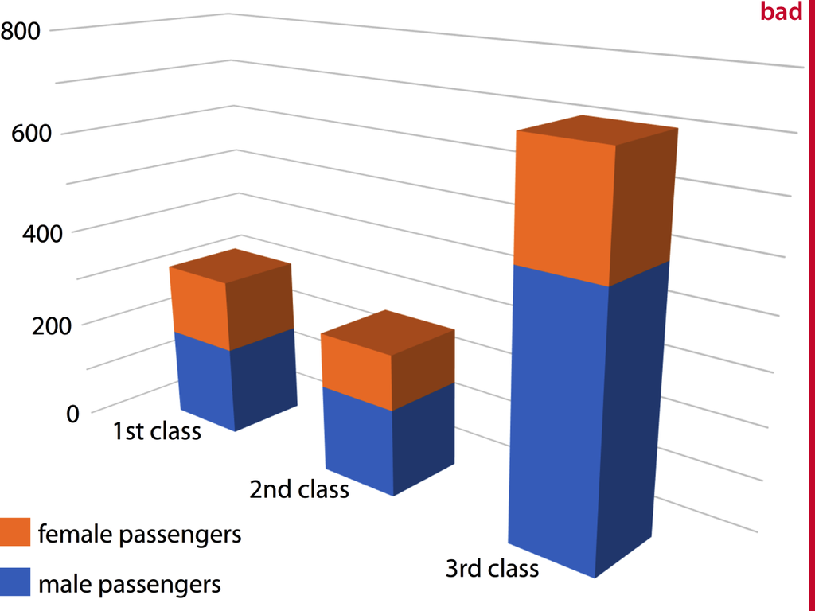

*How many passengers are in first class? How many male passengers are in 3rd class?* Let’s recreate this plot without the gratuitous 3D.

### Exercise 2

Step 1: Copy-and-paste the following data into your exercise document.

```r
titanic <- tribble(
  ~Class, ~Sex, ~n,
  "1st class", "female passengers", 144,
  "1st class", "male passengers", 179,
  "2nd class", "female passengers", 106,
  "2nd class", "male passengers", 171,
  "3rd class", "female passengers", 216,
  "3rd class", "male passengers", 493
)
```

Step 2: Recreate the 3D plot in 2D.

## Guideline 3: Integrate the Graphics and Text

1. Remove legends when possible and label data directly
2. Write an *active* title like a newspaper headline
3. Add explainers

`labs()` adds `title`, `subtitle`, `caption`, and `tag` to ggplot2 objects. It can also be used to overwrite `x`, `y`, and legend titles. Use `NULL` to remove a label entirely (not `""`). `ggtitle()`, `xlab()`, and `ylab()` are alternatives, but I prefer to exclusively use `labs()` for clarity.

### Exercise 3

Step 1: Duplicate the titanic example from above.

Step 2: Add a newspaper like headline with `labs(title = "")`.

Step 3: Add the sources of the data with `caption = "Data from library(titanic)"`.

### Exercise 4

[`library(ggtext)`](https://github.com/wilkelab/ggtext) is a useful library for extending text functionality in ggplot2.

Step 1: Install `ggtext` with `install.packages("ggtext")` and load the package with `library(ggtext)`.

Step 2: Duplicate the titanic example from above.

Step 3: We want to compare the sexes within classes. Add `position = "dodge"` inside `geom_col()`.

Step 4: Add the following code:

```
  theme_minimal() +
  theme(plot.title = element_markdown())
```

Step 5: Add the following code:

```
  labs(
    title = "All three classes had more
    <span style='color:#00BFC4;'>male passengers</span> than
    <span style='color:#F8766D;'>female passengers</span>",
    x = NULL,
    y = NULL
  )
```

Step 6: Add `guides(fill = FALSE)` to remove the legend.

**Tip:** I found [this solution](https://stackoverflow.com/questions/49735290/ggplot2-color-individual-words-in-title-to-match-colors-of-groups) by Googline “add color in ggplot2 title”.

`annotate()`, `geom_text()`, and `geom_text_repel()` from `library(ggrepel)` are useful for labeling data directly and adding explainers. Consider directly labeling bars instead of using y-axes, labeling lines instead of using legends for colors, and directly labeling points. Also, consider how an explainer or annotation layer can enhance a data visualization. [This example](https://questionsindataviz.com/2018/01/06/is-white-space-always-your-friend/) by Neil Richards about the name Neil is a great demonstration of explainers.

## Guideline 4: Avoid the Spaghetti Chart

> "Sometimes we face the challenge of including lots of data in a single graph but we don’t need to try to pack everything into a single graph.

Faceting or using small multiples is a useful way to declutter a busy data visualization. We’ve already encountered faceting multiple times because it is so natural in ggplot2. With effective small multiples, if a reader understand how to read one small multiple then they should understand how to read all of the multiples. Two tips:

1. Arrange the small multiples in a logical order
2. Use the same layout, size, font, and color in each small multiple

## Guideline 5: Start with Gray

> “Whenever you make a graph, start with all gray data elements. By doing so, you force yourself to be purposeful and strategic in your use of color, labels, and other elements.”

[`library(gghighlight)`](https://cran.r-project.org/web/packages/gghighlight/vignettes/gghighlight.html) complements this idea of starting with gray. Let’s consider an example using the Gapminder data.

### Exercise 5

Step 1: Install and load the `gghighlight` package and `gapminder` package.

Step 2: Copy-and-paste the following code to create a data frame with the cumulative change in per-capita GDP in European countries:

```
data <- gapminder %>%
  filter(continent %in% c("Europe")) %>%
  group_by(country) %>%
  mutate(pcgpd_change = ifelse(year == 1952, 0, gdpPercap - lag(gdpPercap))) %>%
  mutate(pcgpd_change = cumsum(pcgpd_change))
```

Step 3: Create a line plot with `x = year`, `y = pcgdp_change`, `group = country`, and `geom_line()`.

Step 4: Add the following code to clean up the x-axis and y-axis.

```
  scale_x_continuous(expand = expand_scale(mult = c(0.002, 0)),
                     breaks = c(seq(1950, 2010, 10)),
                     limits = c(1950, 2010)) +
  scale_y_continuous(expand = expand_scale(mult = c(0, 0.002)),
                     breaks = 0:8 * 5000,
                     labels = scales::dollar,
                     limits = c(0, 40000)) +
  labs(x = "Year",
       y = "Change in per-capita GDP (US dollars)")
```

Step 5: Suppose we want to highlight the two best-performing counties. We could add a new variable and tinker with the colors or we can use `library(gghighlight)`. Switch `group` to `color` in you existing code and add `gghighlight(max(pcgpd_change) > 35000)`.

Step 6: Above the data viz, add `theme_set(theme_minimal())`. This changes the default theme for the entire R session.